# R tricks used in bioinformatics scripts

Here are a collection of R “tricks” that I’ve pulled out from the notebooks in the ‘bioinformatics’ folder. I suspect some of these might get updated/changed depending on the tastes of the person leading the workshop, but this is a start! I have them organized by the script they came from.

Warning: some of these code chunks don’t run. For those that don’t, I’ve tried to reference the line from the original script so you can see it in context.

## 1_cellranger-demo.Rmd

## 2_qc.Rmd

Use file.path() to paste paths together

```r
file.path(cr.outs, "filtered_feature_bc_matrix.h5")
```

```
[1] "/hpc/group/chsi-mic-2022/data/pbmc8k/pbmc8k/outs/filtered_feature_bc_matrix.h5"
```

Use pipes to link together functions

Use head() to see the first few lines of a dataframe

|  | orig.ident | nCount_RNA | nFeature_RNA |
| --- | --- | --- | --- |
| AAACCTGAGCATCATC-1 | SeuratProject | 3619 | 1631 |
| AAACCTGAGCTAACTC-1 | SeuratProject | 2200 | 1169 |
| AAACCTGAGCTAGTGG-1 | SeuratProject | 5472 | 1917 |
| AAACCTGCACATTAGC-1 | SeuratProject | 3374 | 1343 |
| AAACCTGCACTGTTAG-1 | SeuratProject | 5941 | 2241 |
| AAACCTGCATAGTAAG-1 | SeuratProject | 5369 | 2048 |

Pull out elements buried in complex data structures

Look at row names

```r
rownames(curr.count)[1:10]
```

```
 [1] "MIR1302-2HG" "FAM138A"     "OR4F5"       "AL627309.1"  "AL627309.3"  "AL627309.2"  "AL627309.5"
 [8] "AL627309.4"  "AP006222.2"  "AL732372.1"
```

Search for text matches with grepl()

```r
grepl("^MT-", rownames(curr.count))[1:3]
```

```
[1] FALSE FALSE FALSE
```

ggplot elements

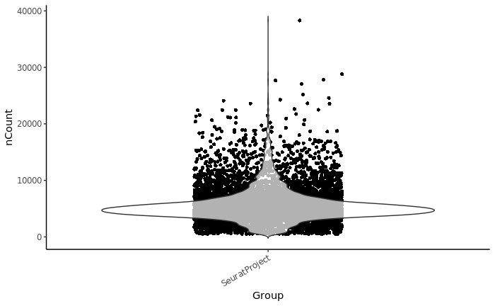

Summarize data in a dataframe

| threshold | ncells_filtered | ncells_kept |
| --- | --- | --- |
| 1000 | 144 | 8644 |

Count the number of rows

```r
nrow(pbmc8k@meta.data)
```

Subset a Seurat object based on metadata criteria

```r
cl <- 6 # min number of total reads per cell (nCount is analogous to library size or total number of reads)
ch <- 11 # max number of total reads per cell
fl <- 5.5 # min number of gene features per cell
seuobj_filt <- subset(seuobj,
         nCount_RNA > exp(cl) &
         nCount_RNA < exp(ch) &
         nFeature_RNA > exp(fl))
```

## 3_load_transformCounts.Rmd

Use basename()

```r
datadirs
basename(datadirs)
```

Use gsub()

```r
sampleNames <- gsub("_10x","", basename(datadirs))
sampleNames
```

For-loops

```r
seulist <- list()
for(i in 1:length(sampleNames)){
  seulist[[i]] <- readin_10x_to_SO(sample = sampleNames[i], path = datadirs[i])
}
names(seulist) <- sampleNames
seulist
```

Make a function

```r
add_mt <- function(so){
  so[["percent.mt"]] <- PercentageFeatureSet(so, pattern = "^mt-")
  return(so)
}
```

Map a function over a list

```r
seulist %>%
  map(~add_mt(.x)) -> seulist.mt

seulist.mt %>%
  map(~head(.x@meta.data))
```

Group and then summarize data in a dataframe

```r
seulist %>%
  map_dfr(~.x@meta.data, .id = "seuobj") %>%
  group_by(seuobj) %>%
  summarize(min = min(nFeature_RNA),
            mean = mean(nFeature_RNA),
            max = max(nFeature_RNA))
```

FYI, there is info about how Seurat objects are structured in this script, e.g. see line 159

Use dim() and create a dataframe

```r
curr.counts <- tem@assays$RNA@counts
dim(curr.counts) # 12571 features as rows and 1457 cells as columns
curr.data <- tem@assays$RNA@data
df <- data.frame(count = curr.counts[,i], data = curr.data[,i], feature = row.names(curr.counts), row.names = NULL)
head(df)
```

## 4_clustering_annotation.Rmd

Read in R objects (and save them)

```r
seulist <- readRDS(file.path(intermeddir, "seulist_drc.rds"))
```

Index elements of a list

```r
tem <- seulist[["Tem"]]
```

Use coord_equal() … line 238

```r
#DimPlot(seulist.drc[["Trm"]], reduction = "tsne") + ggtitle("Trm") + coord_equal()
```

Use pull() and unique()… line 283

```r
# tem@meta.data %>%
#   pull(seurat_clusters) %>% unique()
```

Use arrange()… line 305

```r
# cluster0.markers %>%
#   arrange(-avg_log2FC) %>%
#   head(n = 5)
```

## 5_de.Rmd

Put ggplots together with cowplot… line 189

```r
# library(cowplot)
# plot_grid(DimPlot(tem, reduction = "tsne"),
#           FeaturePlot(tem, features = c("Hmgb2")))
```

Use ncol() … line 90

```r
#ncol(x = tem.0) # 317 cells
```

Use slice_max()… line 151

```r
# all.markers %>%
#   group_by(cluster) %>%
#   slice_max(n = 3, order_by = avg_log2FC) %>%
#   arrange(cluster, -avg_log2FC)
# # note that this uses slice_max() and avg_log2FC is arranged from high to low with "-"
```

Use slice_min()… line 160

```r
# all.markers %>%
#   group_by(cluster) %>%
#   slice_min(n = 3, order_by = avg_log2FC) %>%
#   arrange(cluster, avg_log2FC)
# # note that this uses slice_min() and avg_log2FC is arranged from low to high
```

Use bind_rows()… line 176

```r
# upGenes %>%
#   bind_rows(downGenes) -> topGenes
```

Use rownames_to_column() … line 276

```r
# p4v2markers %>%
#   rownames_to_column(var = "gene") %>%
#   filter(gene == "Pdcd1")
```

## 6_trajectory.Rmd

Use package.version()

```r
library(monocle); package.version("monocle")
```

Merge Seurat objects… line 65

```r
# comb <- merge(trm.rn, disttrm.rn)
```

Use Cells() to get cell names from a Seurat object…line 83 Use str_split() Use map_dfr() Use mutate()

```r
# Cells(comb) %>%
#   str_split("_") %>%
#   map_dfr(~data.frame(prefix = .x[1], orig.cellname = .x[2])) %>%
#   mutate(new.cellname = Cells(comb)) -> cellname.df
```

Other data structures, e.g. AnnotatedDataFrame… line 127

```r
# pd.adf <- new("AnnotatedDataFrame", data = pd)
```

FYI, there is info about how CellDataSet (monocle) objects are structured in this script, e.g. see line 130

R package monocle imports BiocGenerics::estimateSizeFactors()… line 141

```r
# cds.es <- estimateSizeFactors(cds)
```

Model formula strings, e.g. ~orig.ident… line 183

```r
# diff_test_res <- differentialGeneTest(cds.exprs, fullModelFormulaStr = "~orig.ident", cores = 2)
```

More grepl-ing… line 272

```r
# marker_genes <- grep('^Il', all.ordered.genes, value = T)
```

Index with rownames… line 275

```r
# cds.mg <- cds.oc[marker_genes,]
# cds.mg
```

More model formula strings… line 281

```r
# diff_test_res2 <- differentialGeneTest(cds.mg, fullModelFormulaStr = "~sm.ns(Pseudotime)")
```